# Tugas MPDW Kuliah 2

Sabitala Dinika G1401231089

2025-08-29

# 1 Impor Data

```r
library(lmtest)
library(readxl)
dt <- read_xlsx("~/punya dinoy/kuliah/Semester 5/MPDW/Book1.xlsx")
dt
```

```
## # A tibble: 15 × 2
##      IPM Tahun
##    <dbl> <dbl>
##  1  64.4  2010
##  2  64.8  2011
##  3  65.7  2012
##  4  66.7  2013
##  5  67.4  2014
##  6  67.8  2015
##  7  68.3  2016
##  8  69.1  2017
##  9  69.7  2018
## 10  70.6  2019
## 11  71.6  2020
## 12  71.8  2021
## 13  72.4  2022
## 14  73.0  2023
## 15  73.6  2024
```

Data di atas merupakan data IPM (Indeks Pembangunan Manusia) di Kabupaten Bogor tahun 2010-2024 yang diambil dari website resmi BPS Kabupaten Bogor.

# 2 Eksplorasi Data

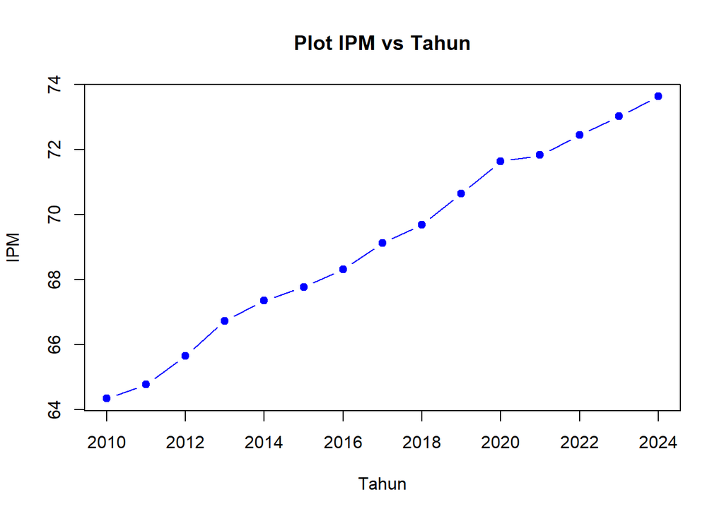

```r
plot(dt$Tahun, dt$IPM,
     type = "b",           # "p" titik, "l" garis, "b" titik+garis
     pch = 19,             # bentuk titik (19 = bulat solid)
     col = "blue",         # warna
     xlab = "Tahun",
     ylab = "IPM",
     main = "Plot IPM vs Tahun")
```

Dari grafik ini, ada indikasi kuat autokorelasi positif, karena data mengikuti tren naik yang mulus, artinya nilai IPM sekarang dipengaruhi nilai IPM tahun sebelumnya. Namun untuk memastikan, perlu uji formal seperti Durbin–Watson atau cek ACF residual.

# 3 Pemodelan Linear

```r
model <- lm(formula = IPM ~ Tahun, data = dt)
summary(model)
```

```
##
## Call:
## lm(formula = IPM ~ Tahun, data = dt)
##
## Residuals:
##      Min       1Q   Median       3Q      Max
## -0.31150 -0.12900 -0.05275  0.08475  0.47475
##
## Coefficients:
##               Estimate Std. Error t value Pr(>|t|)
## (Intercept) -1.290e+03  2.649e+01  -48.69 4.23e-16 ***
## Tahun        6.737e-01  1.313e-02   51.30  < 2e-16 ***
## ---
## Signif. codes:  0 '***' 0.001 '**' 0.01 '*' 0.05 '.' 0.1 ' ' 1
##
## Residual standard error: 0.2198 on 13 degrees of freedom
## Multiple R-squared:  0.9951, Adjusted R-squared:  0.9947
## F-statistic:  2632 on 1 and 13 DF,  p-value: < 2.2e-16
```

Ada hubungan sangat kuat dan signifikan antara Tahun dan IPM. Model menunjukkan bahwa setiap tahun, IPM rata-rata naik sekitar 0.67 poin.

# 4 Uji Kebebasan Antar Sisaan (Autokorelasi)

## 4.1 Uji Formal (Durbin Watson)

Hipotesis:

```r
dwtest(model)
```

```
##
##  Durbin-Watson test
##
## data:  model
## DW = 1.2809, p-value = 0.03421
## alternative hypothesis: true autocorrelation is greater than 0
```

Berdasarkan uji Durbin–Watson, diperoleh nilai DW sebesar 1.2809 dengan p-value 0.03421 (< 0.05), yang artinya tolak H0. Hal ini menunjukkan bahwa terdapat autokorelasi pada residual model regresi, sehingga asumsi independensi residual tidak terpenuhi.

## 4.2 ACF dan PACF

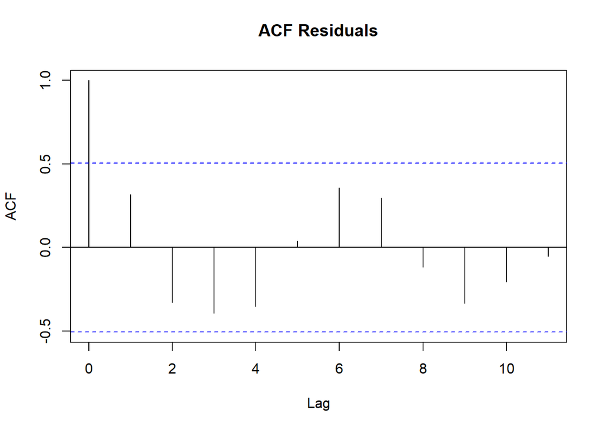

```r
# residual
resid_model <- residuals(model)

# Plot ACF dan PACF residual
acf(resid_model, main = "ACF Residuals")
```

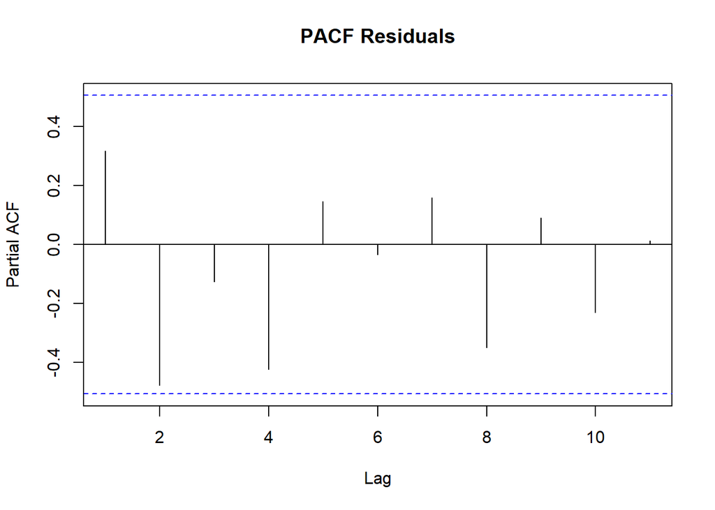

```r
pacf(resid_model, main = "PACF Residuals")
```

# 5 Penanganan Autokorelasi

## 5.1 Cochrane-Orcutt

```r
library(orcutt)
cochrane.orcutt(model)
```

```
## Cochrane-orcutt estimation for first order autocorrelation
##
## Call:
## lm(formula = IPM ~ Tahun, data = dt)
##
##  number of interaction: 8
##  rho 0.357935
##
## Durbin-Watson statistic
## (original):    1.28085 , p-value: 3.421e-02
## (transformed): 1.57858 , p-value: 1.223e-01
##
##  coefficients:
##  (Intercept)        Tahun
## -1274.632161     0.666224
```

Berdasarkan uji Durbin-Watson sebelum transformasi diperoleh nilai p-value = 0.03421 (< 0.05) yang menunjukkan adanya autokorelasi positif pada residual. Namun setelah dilakukan transformasi dengan metode Cochrane-Orcutt, p-value meningkat menjadi 0.1223 (> 0.05), sehingga dapat disimpulkan bahwa autokorelasi tidak lagi signifikan. Dengan demikian, metode Cochrane-Orcutt berhasil mengatasi masalah autokorelasi pada model regresi.

## 5.2 Hildreth-Lu

```r
rho = c(seq(0.1, 0.8, by = 0.1), seq (0.90, 0.99, by=0.01))

hildreth.lu <- function(rho, model){
x <- model.matrix (model) [, -1]
y <- model.response (model.frame (model))
n <- length(y)
t <- 2:n
y <- y[t] - rho * y[t-1]
x <- x[t] - rho * x[t-1]
return(lm(y ~ x))}
```

```r
y <- dt$IPM
x <- dt$Tahun

fit <- lm(y ~ x)
tab <- data.frame('rho' = rho,
                  'SSE' = sapply(rho, function(r) {deviance(hildreth.lu(r, fit))}))
round(tab, 4)
```

```
##     rho    SSE
## 1  0.10 0.5870
## 2  0.20 0.5636
## 3  0.30 0.5514
## 4  0.40 0.5505
## 5  0.50 0.5609
## 6  0.60 0.5826
## 7  0.70 0.6155
## 8  0.80 0.6597
## 9  0.90 0.7152
## 10 0.91 0.7214
## 11 0.92 0.7277
## 12 0.93 0.7341
## 13 0.94 0.7406
## 14 0.95 0.7472
## 15 0.96 0.7539
## 16 0.97 0.7608
## 17 0.98 0.7677
## 18 0.99 0.7748
```

Berdasarkan metode Hildreth-Lu, diperoleh nilai $\rho$ yang meminimalkan SSE yaitu $\rho = 0.40$ dengan SSE = 0.5505. Hal ini menunjukkan bahwa nilai $\rho = 0.40$ merupakan estimasi terbaik untuk mengoreksi autokorelasi pada model regresi. Namun untuk memperoleh estimasi yang lebih presisi, dilakukan pencarian lanjutan pada rentang $\rho = 0.30$ hingga $\rho = 0.50$ dengan increment 0.01.

```r
rho = c(seq(0.3, 0.5, by=0.01))
tab <- data.frame('rho' = rho,
                  'SSE' = sapply(rho, function(r) {deviance(hildreth.lu(r, fit))}))
round(tab, 4)
```

```
##     rho    SSE
## 1  0.30 0.5514
## 2  0.31 0.5508
## 3  0.32 0.5503
## 4  0.33 0.5500
## 5  0.34 0.5497
## 6  0.35 0.5496
## 7  0.36 0.5495
## 8  0.37 0.5496
## 9  0.38 0.5498
## 10 0.39 0.5501
## 11 0.40 0.5505
## 12 0.41 0.5511
## 13 0.42 0.5517
## 14 0.43 0.5525
## 15 0.44 0.5533
## 16 0.45 0.5543
## 17 0.46 0.5554
## 18 0.47 0.5566
## 19 0.48 0.5579
## 20 0.49 0.5594
## 21 0.50 0.5609
```

Berdasarkan pencarian lanjutan tersebut, diperoleh nilai $\rho$ yang meminimalkan SSE yaitu $\rho = 0.36$ dengan SSE = 0.5495. Hal ini menunjukkan bahwa nilai $\rho = 0.36$ merupakan estimasi terbaik untuk mengoreksi autokorelasi pada model regresi sehingga model hasil transformasi dapat digunakan sebagai model akhir.

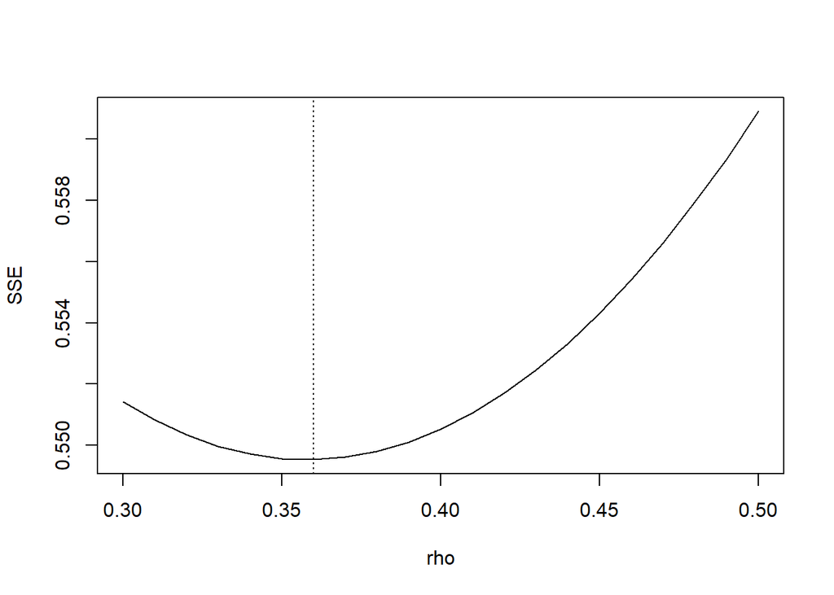

```r
plot(SSE ~ rho, tab, type = 'l')
abline(v = tab[tab$SSE == min(tab$SSE), 'rho'], lty = 3)
```

Berdasarkan grafik Hildreth-Lu pun terlihat kurva yang di mana titik minimum (SSE minimum) berada pada $\rho = 0.36$.

```r
fit <- hildreth.lu(0.36, fit)
summary(fit)
```

```
##
## Call:
## lm(formula = y ~ x)
##
## Residuals:
##      Min       1Q   Median       3Q      Max
## -0.31779 -0.12788 -0.07025  0.10328  0.42703
##
## Coefficients:
##               Estimate Std. Error t value Pr(>|t|)
## (Intercept) -815.70296   28.63195  -28.49 2.17e-12 ***
## x              0.66618    0.02217   30.05 1.15e-12 ***
## ---
## Signif. codes:  0 '***' 0.001 '**' 0.01 '*' 0.05 '.' 0.1 ' ' 1
##
## Residual standard error: 0.214 on 12 degrees of freedom
## Multiple R-squared:  0.9869, Adjusted R-squared:  0.9858
## F-statistic:   903 on 1 and 12 DF,  p-value: 1.154e-12
```

```r
dwtest(fit)
```

```
##
##  Durbin-Watson test
##
## data:  fit
## DW = 1.5809, p-value = 0.1233
## alternative hypothesis: true autocorrelation is greater than 0
```

Berdasarkan uji Durbin–Watson setelah dilakukan transformasi Hildreth–Lu, diperoleh DW = 1.5809 dengan p-value = 0.1233 (> 0.05), yang artinya tak tolak H0. Hal ini menunjukkan bahwa tidak terdapat autokorelasi positif yang signifikan pada residual, sehingga metode Hildreth–Lu berhasil memperbaiki masalah autokorelasi pada model.

# 6 Kesimpulan

Dengan demikian, dapat disimpulkan bahwa adanya autokorelasi pada data IPM Kabupaten Bogor berhasil diatasi baik dengan metode Cochrane-Orcutt maupun Hildreth-Lu, ditunjukkan oleh nilai p-value uji Durbin–Watson setelah transformasi yang lebih besar dari 0.05 pada kedua metode.